# tree-based_answers

## Exercise 1.5

Use the bagging approach in order to analyze this data. What test MSE do you obtain? Use the importance() function to determine which variables are most important.

```r
# Check the number of columns, we need columns - 1 for the number of features.
ncol(Carseats)
```

```
## [1] 11
```

```r
# Create a bagging model using the randomForest library.
bagging_carseats = randomForest(Sales ~., data=Carseats, subset=train, mtry=(ncol(Carseats) - 1), ntree=500)

# Make a prediction and compute MSE.
bagging_prediction = predict(bagging_carseats, Carseats[-train, ])
mean((Carseats[-train, ]$Sales - bagging_prediction)^2)
```

```
## [1] 2.396877
```

```r
# Find the most important variables
importance(bagging_carseats)
```

```
##             IncNodePurity
## CompPrice       268.96248
## Income          123.94210
## Advertising     197.41885
## Population       82.59870
## Price           610.65221
## ShelveLoc       734.47038
## Age             190.62920
## Education        54.26242
## Urban            11.20717
## US               13.12564
```

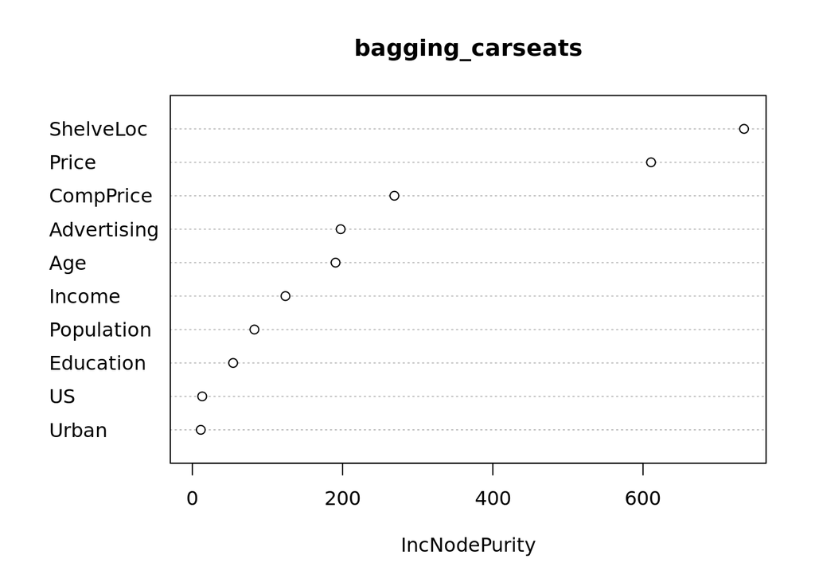

```r
varImpPlot(bagging_carseats)
```

## Exercise 1.6

Use the random forest algorithm to build a model. What test MSE do you obtain? Use the importance() function to determine which variables are most important.

```r
forest_carseats = randomForest(Sales ~., data=Carseats, subset=train, mtry=sqrt(ncol(Carseats)), ntree=500)

forest_prediction = predict(forest_carseats, Carseats[-train, ])
mean((Carseats[-train,]$Sales - forest_prediction)^2)
```

```
## [1] 2.833118
```

## Exercise 1.7

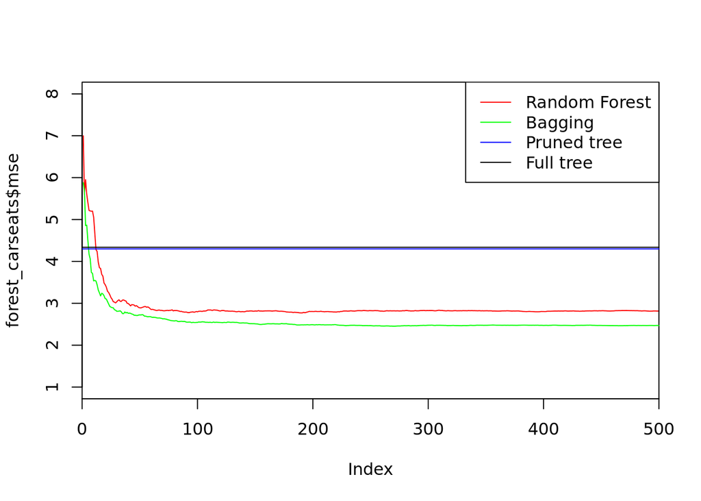

```r
{plot(forest_carseats$mse, type='l', ylim = c(1,8), xlim=c(0,500), xaxs='i', col='red')
lines(bagging_carseats$mse, type='l', col='green')
abline(MSE_pruned, 0, col='blue')
abline(MSE_tree, 0, col='black')
legend('topright', c('Random Forest', 'Bagging', 'Pruned tree', 'Full tree'), col = c('red', 'green', 'blue', 'black'), cex = 1, lty = 1)}
```

# Exercise 2:

```r
library(tree)
library(ISLR)
```

## Exercise 2.1

Create a training set containing a random sample of 800 observations, and a test set containing the remaining observations.

```r
set.seed(1013)
str(OJ)
```

```
## 'data.frame':    1070 obs. of  18 variables:
##  $ Purchase      : Factor w/ 2 levels "CH","MM": 1 1 1 2 1 1 1 1 1 1 ...
##  $ WeekofPurchase: num  237 239 245 227 228 230 232 234 235 238 ...
##  $ StoreID       : num  1 1 1 1 7 7 7 7 7 7 ...
##  $ PriceCH       : num  1.75 1.75 1.86 1.69 1.69 1.69 1.69 1.75 1.75 1.75 ...
##  $ PriceMM       : num  1.99 1.99 2.09 1.69 1.69 1.99 1.99 1.99 1.99 1.99 ...
##  $ DiscCH        : num  0 0 0.17 0 0 0 0 0 0 0 ...
##  $ DiscMM        : num  0 0.3 0 0 0 0 0.4 0.4 0.4 0.4 ...
##  $ SpecialCH     : num  0 0 0 0 0 0 1 1 0 0 ...
##  $ SpecialMM     : num  0 1 0 0 0 1 1 0 0 0 ...
##  $ LoyalCH       : num  0.5 0.6 0.68 0.4 0.957 ...
##  $ SalePriceMM   : num  1.99 1.69 2.09 1.69 1.69 1.99 1.59 1.59 1.59 1.59 ...
##  $ SalePriceCH   : num  1.75 1.75 1.69 1.69 1.69 1.69 1.69 1.75 1.75 1.75 ...
##  $ PriceDiff     : num  0.24 -0.06 0.4 0 0 0.3 -0.1 -0.16 -0.16 -0.16 ...
##  $ Store7        : Factor w/ 2 levels "No","Yes": 1 1 1 1 2 2 2 2 2 2 ...
##  $ PctDiscMM     : num  0 0.151 0 0 0 ...
##  $ PctDiscCH     : num  0 0 0.0914 0 0 ...
##  $ ListPriceDiff : num  0.24 0.24 0.23 0 0 0.3 0.3 0.24 0.24 0.24 ...
##  $ STORE         : num  1 1 1 1 0 0 0 0 0 0 ...
```

```r
train_indices = sample(nrow(OJ), 800, FALSE)
train = OJ[train_indices, ]
test = OJ[-train_indices, ]
```

## Exercise 2.2

Fit a tree to the training data, with Purchase as the response and the other variables as predictors. Use the summary() function to produce summary statistics about the tree, and describe the results obtained. What is the training error rate? How many terminal nodes does the tree have?

```r
OJ_tree = tree(Purchase ~ ., data=train)
summary(OJ_tree)
```

```
##
## Classification tree:
## tree(formula = Purchase ~ ., data = train)
## Variables actually used in tree construction:
## [1] "LoyalCH"   "PriceDiff"
## Number of terminal nodes:  7
## Residual mean deviance:  0.7517 = 596.1 / 793
## Misclassification error rate: 0.155 = 124 / 800
```

## Exercise 2.3

Type in the name of the tree object in order to get a detailed text output. Pick one of the terminal nodes, and interpret the information displayed.

```r
OJ_tree
```

```
## node), split, n, deviance, yval, (yprob)
##       * denotes terminal node
##
##  1) root 800 1075.00 CH ( 0.60250 0.39750 )
##    2) LoyalCH < 0.5036 359  422.80 MM ( 0.27577 0.72423 )
##      4) LoyalCH < 0.276142 170  119.10 MM ( 0.11176 0.88824 ) *
##      5) LoyalCH > 0.276142 189  257.50 MM ( 0.42328 0.57672 )
##       10) PriceDiff < 0.05 79   76.79 MM ( 0.18987 0.81013 ) *
##       11) PriceDiff > 0.05 110  148.80 CH ( 0.59091 0.40909 ) *
##    3) LoyalCH > 0.5036 441  343.30 CH ( 0.86848 0.13152 )
##      6) LoyalCH < 0.764572 186  210.30 CH ( 0.74731 0.25269 )
##       12) PriceDiff < -0.165 29   34.16 MM ( 0.27586 0.72414 ) *
##       13) PriceDiff > -0.165 157  140.90 CH ( 0.83439 0.16561 )
##         26) PriceDiff < 0.265 82   95.37 CH ( 0.73171 0.26829 ) *
##         27) PriceDiff > 0.265 75   31.23 CH ( 0.94667 0.05333 ) *
##      7) LoyalCH > 0.764572 255   90.67 CH ( 0.95686 0.04314 ) *
```

## Exercise 2.4

Create a plot of the tree, and interpret the results.

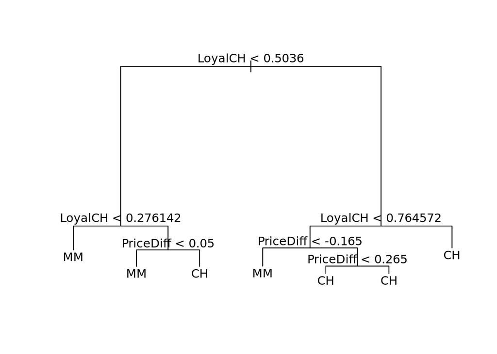

```r
{plot(OJ_tree)
text(OJ_tree, pretty = 0)}
```

## Exercise 2.5

Predict the response on the test data, and produce a confusion matrix comparing the test labels to the predicted test labels. What is the test error rate?

```r
prediction_5 = predict(OJ_tree, test, type='class')
table(test$Purchase, prediction_5)
```

```
##     prediction_5
##       CH  MM
##   CH 152  19
##   MM  32  67
```

```r
# Error rate:
1 - mean(test$Purchase == prediction_5)
```

```
## [1] 0.1888889
```

## Exercise 2.6

Apply the cv.tree() function to the training set in order to determine the optimal tree size.

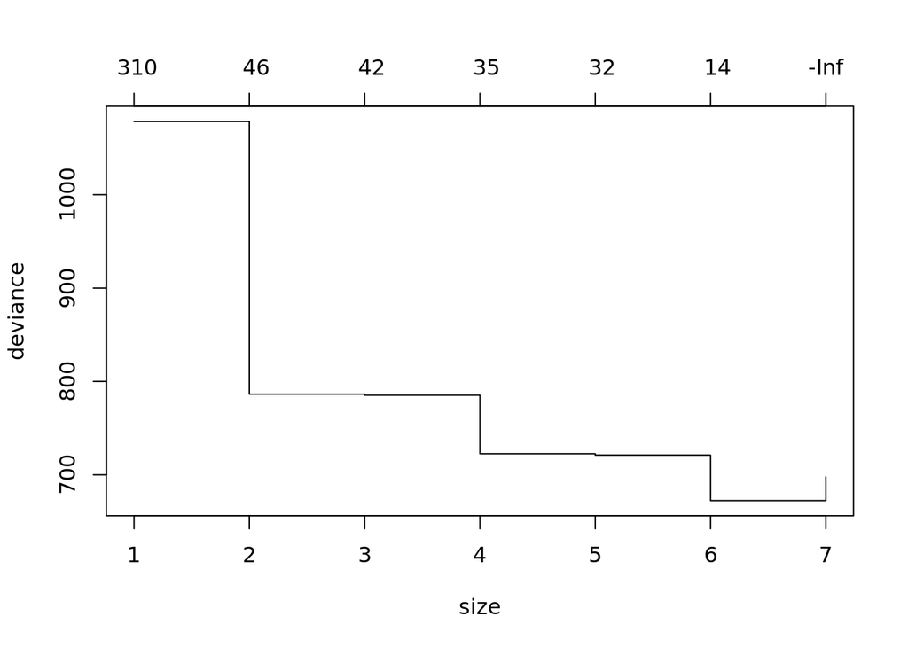

```r
cv_tree = cv.tree(OJ_tree, FUN = prune.tree)
plot(cv_tree)
```

```r
which.min(cv_tree$dev)
```

```
## [1] 2
```

## Exercise 2.7

Produce a plot with tree size on the x-axis and cross-validated classification error rate on the y-axis.

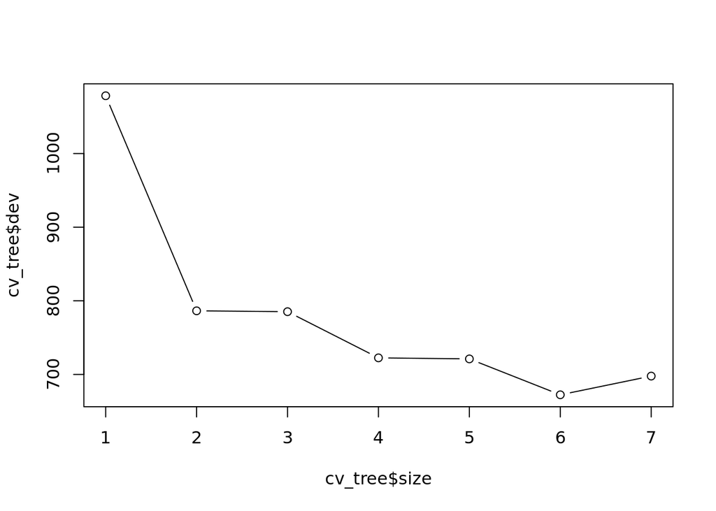

```r
plot(cv_tree$size, cv_tree$dev, type='b')
```

## Exercise 2.8

Which tree size corresponds to the lowest cross-validated classification error rate?

```r
cv_tree$dev
```

```
## [1]  697.7742  672.3676  721.1061  722.5296  785.2427  786.4040 1078.4624
```

## Exercise 2.9

Produce a pruned tree corresponding to the optimal tree size obtained using cross-validation. If cross-validation does not lead to selection of a pruned tree, then create a pruned tree with five terminal nodes.

```r
pruned_tree = prune.tree(OJ_tree, best=6)
```

## Exercise 2.10

Compare the test error rates between the pruned and unpruned trees. Which is higher?

```r
pruned_prediction = predict(pruned_tree, test, type='class')

1 - mean(test$Purchase == pruned_prediction)
```

```
## [1] 0.1888889
```

The results are about equal.

# Exercise 3:

## Exercise 3.1

```r
library(ISLR)
sum(is.na(Hitters$Salary))
```

```
## [1] 59
```

```r
Hitters = Hitters[-which(is.na(Hitters$Salary)), ]
sum(is.na(Hitters$Salary))
```

```
## [1] 0
```

```r
Hitters$Salary = log(Hitters$Salary)
```

## Exercise 3.2

```r
train = 1:200
Hitters.train = Hitters[train, ]
Hitters.test = Hitters[-train, ]
```

## Exercise 3.3

```r
library(gbm)
```

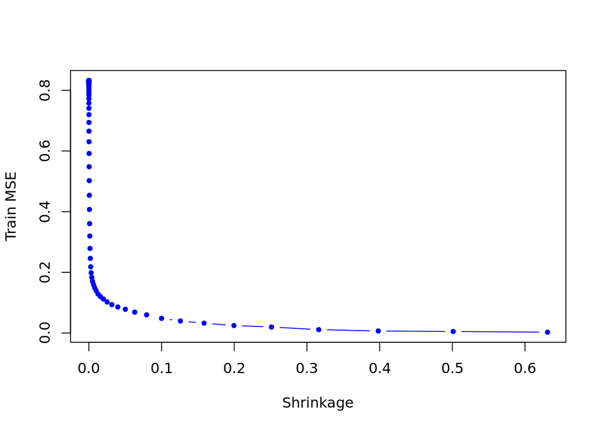

```r
set.seed(103)
pows = seq(-10, -0.2, by=0.1)
lambdas = 10 ^ pows
length.lambdas = length(lambdas)
train.errors = rep(NA, length.lambdas)
test.errors = rep(NA, length.lambdas)
for (i in 1:length.lambdas) {
  boost.hitters = gbm(Salary~., data=Hitters.train, distribution="gaussian", n.trees=1000, shrinkage=lambdas[i])
  train.pred = predict(boost.hitters, Hitters.train, n.trees=1000)
  test.pred = predict(boost.hitters, Hitters.test, n.trees=1000)
  train.errors[i] = mean((Hitters.train$Salary - train.pred)^2)
  test.errors[i] = mean((Hitters.test$Salary - test.pred)^2)
}

plot(lambdas, train.errors, type="b", xlab="Shrinkage", ylab="Train MSE", col="blue", pch=20)
```

## Exercise 3.4

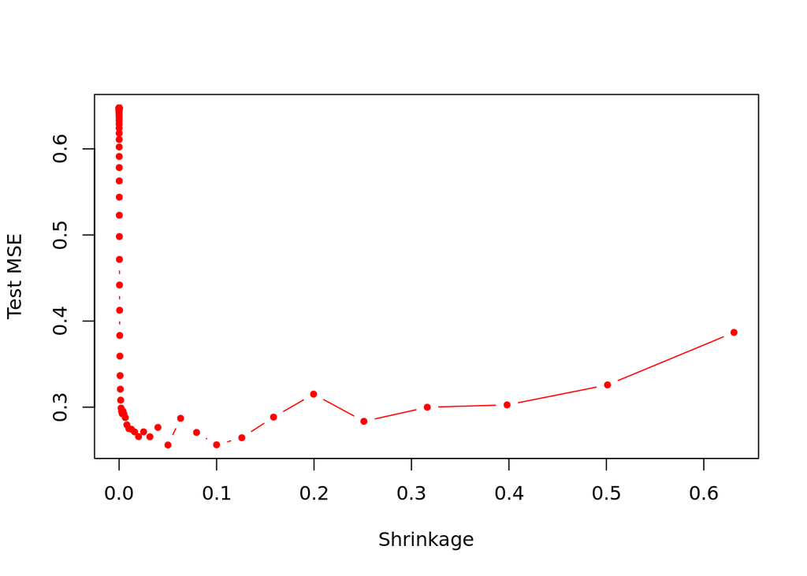

```r
plot(lambdas, test.errors, type="b", xlab="Shrinkage", ylab="Test MSE", col="red", pch=20)
```

```r
min(test.errors)
```

```
## [1] 0.2560507
```

```r
lambdas[which.min(test.errors)]
```

```
## [1] 0.05011872
```

Minimum test error is obtained at $\lambda = 0.05$.

## Exercise 3.5

```r
lm.fit = lm(Salary~., data=Hitters.train)
lm.pred = predict(lm.fit, Hitters.test)
mean((Hitters.test$Salary - lm.pred)^2)
```

```
## [1] 0.4917959
```

```r
library(glmnet)
set.seed(134)
x = model.matrix(Salary~., data=Hitters.train)
y = Hitters.train$Salary
x.test = model.matrix(Salary~., data=Hitters.test)
lasso.fit = glmnet(x, y, alpha=1)
lasso.pred = predict(lasso.fit, s=0.01, newx=x.test)
mean((Hitters.test$Salary - lasso.pred)^2)
```

```
## [1] 0.4700537
```

Both linear model and regularization like Lasso have higher test MSE than boosting.

## Exercise 3.6

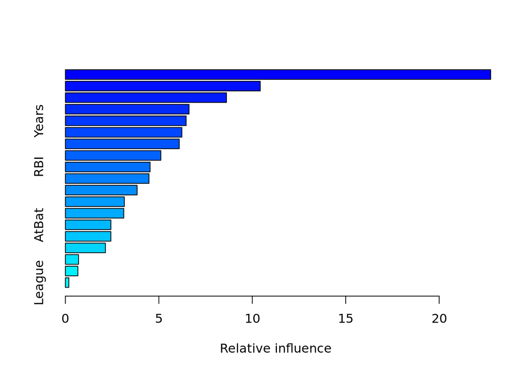

```
##                 var    rel.inf
## CAtBat       CAtBat 22.7562681
## CWalks       CWalks 10.4279674
## CHits         CHits  8.6198109
## PutOuts     PutOuts  6.6159325
## Years         Years  6.4611683
## Walks         Walks  6.2331148
## CRBI           CRBI  6.0926744
## CHmRun       CHmRun  5.1076104
## RBI             RBI  4.5321678
## CRuns         CRuns  4.4728132
## Assists     Assists  3.8366575
## HmRun         HmRun  3.1554038
## Hits           Hits  3.1229284
## AtBat         AtBat  2.4338530
## Errors       Errors  2.4324185
## Runs           Runs  2.1425481
## Division   Division  0.7041949
## NewLeague NewLeague  0.6675446
## League       League  0.1849234
```

```r
boost.best = gbm(Salary~., data=Hitters.train, distribution="gaussian", n.trees=1000, shrinkage=lambdas[which.min(test.errors)])
summary(boost.best)
```

## Exercise 3.7

```r
library(randomForest)
set.seed(21)
rf.hitters = randomForest(Salary~., data=Hitters.train, ntree=500, mtry=19)
rf.pred = predict(rf.hitters, Hitters.test)
mean((Hitters.test$Salary - rf.pred)^2)
```

```
## [1] 0.231884
```

Test MSE for bagging is about $0.23$, which is slightly lower than the best test MSE for boosting.